# #REDWINE DATA ANALYSIS by Yogeshwar Murugan

```
## 'data.frame':    1599 obs. of  13 variables:
##  $ X                   : int  1 2 3 4 5 6 7 8 9 10 ...
##  $ fixed.acidity       : num  7.4 7.8 7.8 11.2 7.4 7.4 7.9 7.3 7.8 7.5 ...
##  $ volatile.acidity    : num  0.7 0.88 0.76 0.28 0.7 0.66 0.6 0.65 0.58 0.5 ...
##  $ citric.acid         : num  0 0 0.04 0.56 0 0 0.06 0 0.02 0.36 ...
##  $ residual.sugar      : num  1.9 2.6 2.3 1.9 1.9 1.8 1.6 1.2 2 6.1 ...
##  $ chlorides           : num  0.076 0.098 0.092 0.075 0.076 0.075 0.069 0.065 0.073 0.071 ...
##  $ free.sulfur.dioxide : num  11 25 15 17 11 13 15 15 9 17 ...
##  $ total.sulfur.dioxide: num  34 67 54 60 34 40 59 21 18 102 ...
##  $ density             : num  0.998 0.997 0.997 0.998 0.998 ...
##  $ pH                  : num  3.51 3.2 3.26 3.16 3.51 3.51 3.3 3.39 3.36 3.35 ...
##  $ sulphates           : num  0.56 0.68 0.65 0.58 0.56 0.56 0.46 0.47 0.57 0.8 ...
##  $ alcohol             : num  9.4 9.8 9.8 9.8 9.4 9.4 9.4 10 9.5 10.5 ...
##  $ quality             : int  5 5 5 6 5 5 5 7 7 5 ...
```

This dataset is public available for research. The details are described in [Cortez et al., 2009].

P. Cortez, A. Cerdeira, F. Almeida, T. Matos and J. Reis. Modeling wine preferences by data mining from physicochemical properties. In Decision Support Systems, Elsevier, 47(4):547-553. ISSN: 0167-9236.

There are 1599 observations and 13 variables in this data set.

Variable description:

Fixed acidity: most acids involved with wine or fixed or nonvolatile (do not evaporate readily)

Volatile acidity: the amount of acetic acid in wine, which at too high of levels can lead to an unpleasant, vinegar taste

Citric acid: found in small quantities, citric acid can add ‘freshness’ and flavor to wines

Residual sugar: the amount of sugar remaining after fermentation stops, it’s rare to find wines with less than 1 gram/liter and wines with greater than 45 grams/liter are considered sweet

Chlorides: the amount of salt in the wine

Free sulfur dioxide: the free form of SO2 exists in equilibrium between molecular SO2 (as a dissolved gas) and bisulfite ion; it prevents microbial growth and the oxidation of wine

Total sulfur dioxide: amount of free and bound forms of S02; in low concentrations, SO2 is mostly undetectable in wine, but at free SO2 concentrations over 50 ppm, SO2 becomes evident in the nose and taste of wine

Density: the density of water is close to that of water depending on the percent alcohol and sugar content

pH: describes how acidic or basic a wine is on a scale from 0 (very acidic) to 14 (very basic); most wines are between 3-4 on the pH scale

Sulphates: a wine additive which can contribute to sulfur dioxide gas (S02) levels, wich acts as an antimicrobial and antioxidant

Alcohol: the percent alcohol content of the wine

Quality: output variable (based on sensory data, score between 0 and 10)

# Univariate Plots Section

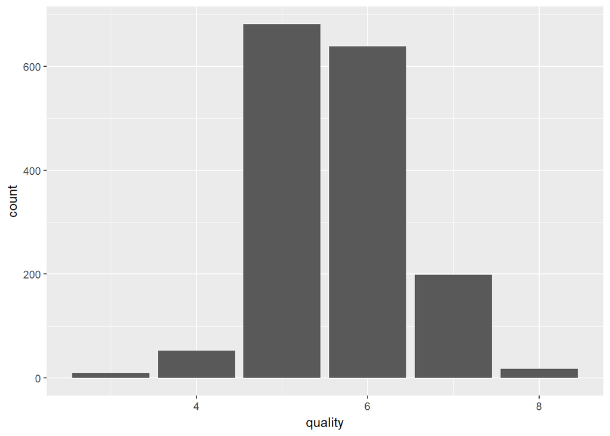

Rated on a scale from 1 to 10, has very few exceptionally high or low quality ratings. Qualities 5 and 6 seem to be the highest in count.

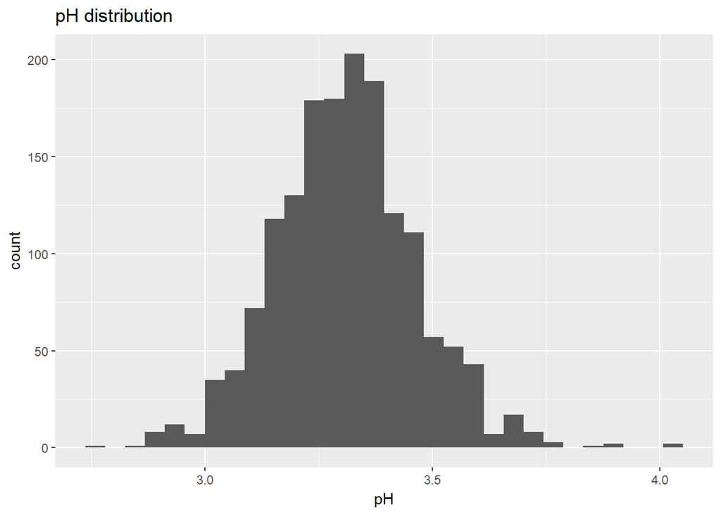

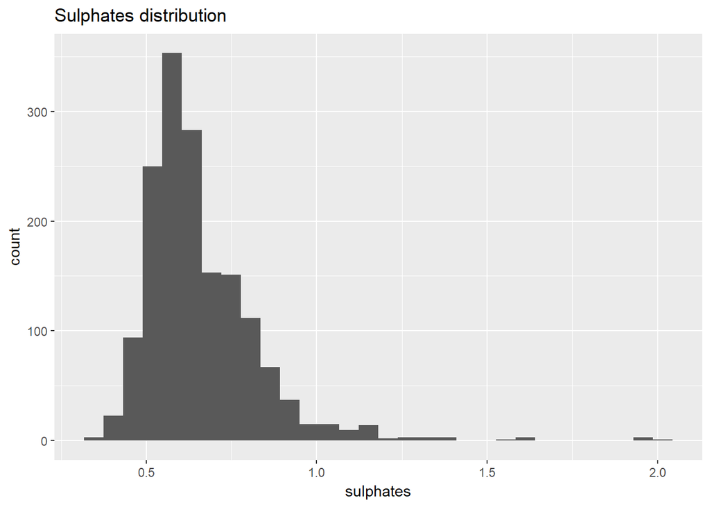

Sulphates are positively skewed, with highest count ranging between 0.5 to 0.6. There seem to be outliers at 2.0.

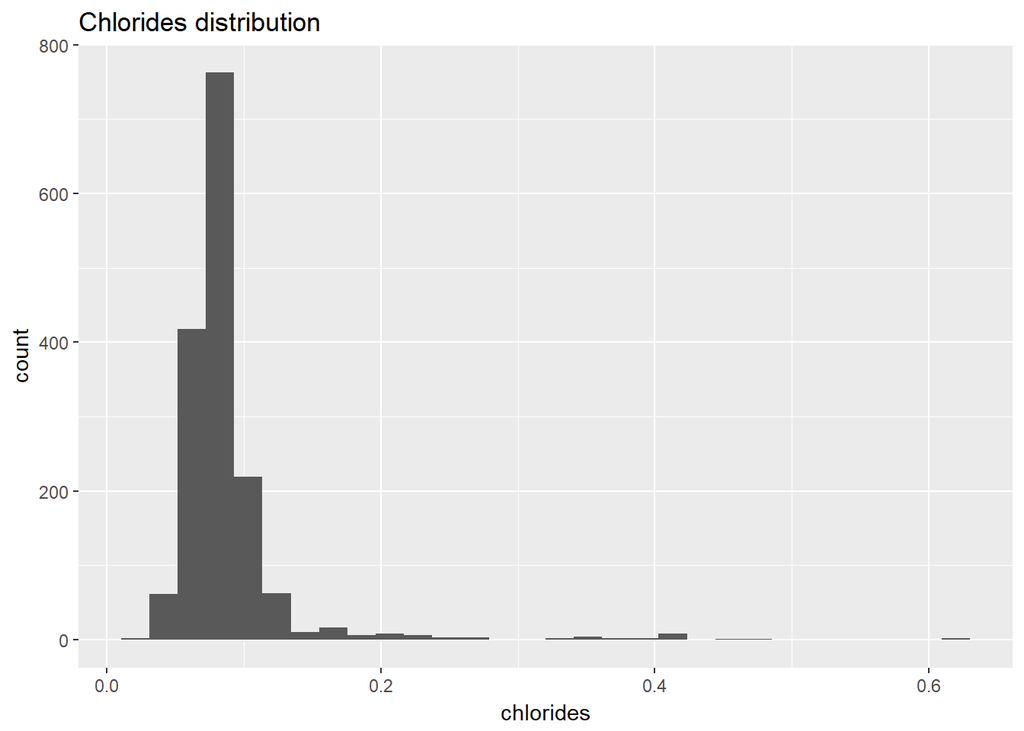

Chlorides are heavily postive skewed, with a center around 0.075.

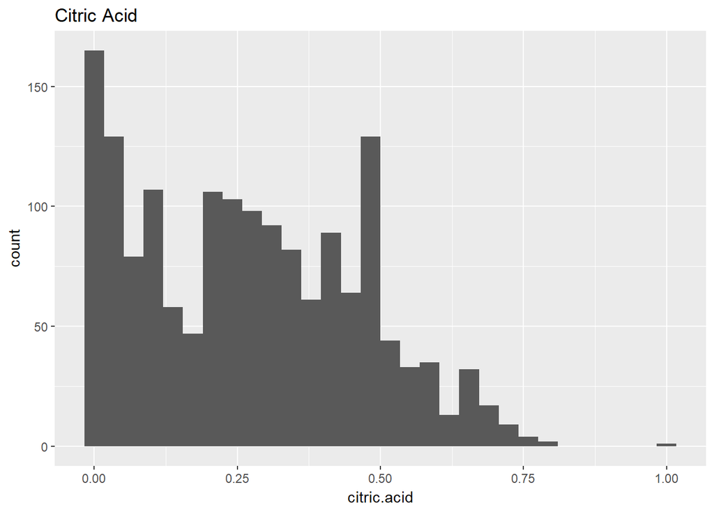

Citric acid looks nearly Trimodal, with a peak at 0.0 and nearly constantly decreasing values until another peak value at 0.25 and a third peak at 0.5.

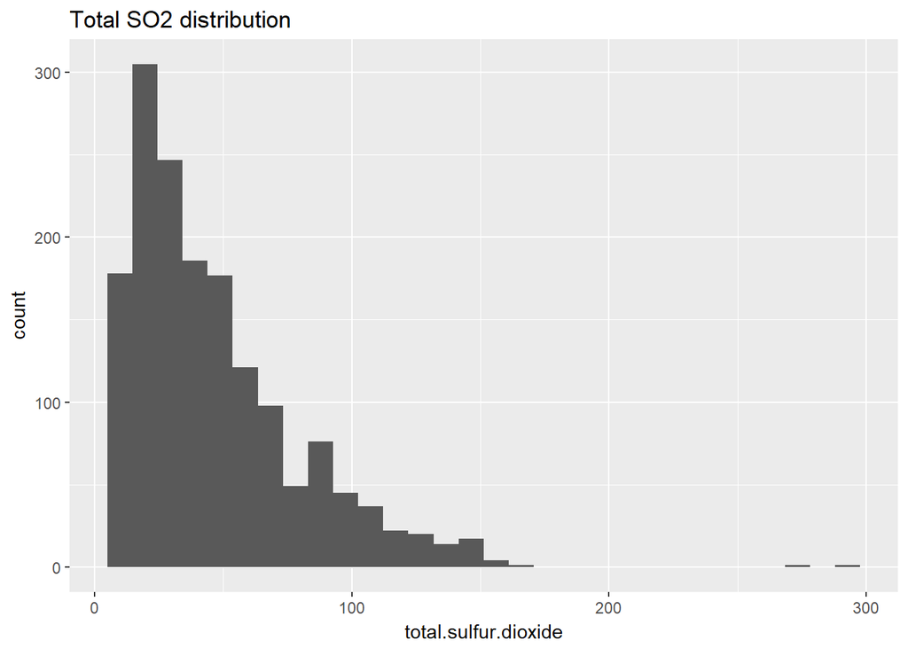

Sulfur Dioxide also is heavily positively skewed, with centre at 20 and extending upto 150.

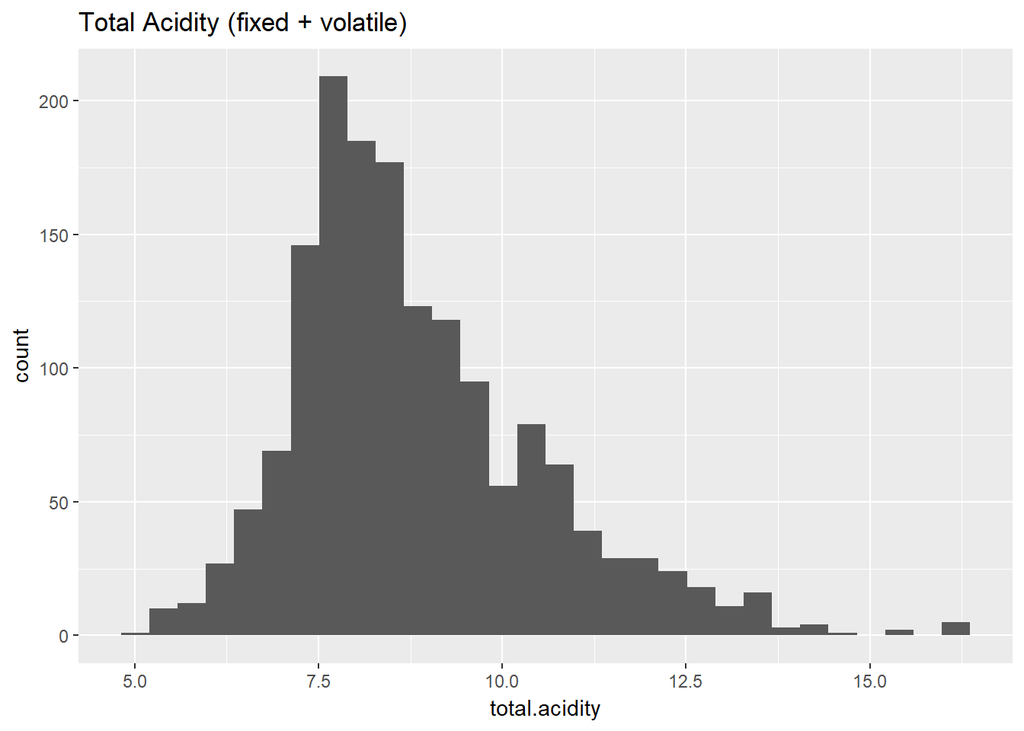

Total acidity of a wine is calcualted by summing up Fixed acidity and Volatile acidity. Hence, ‘Total.acidity’ was calculated variable by adding ‘fixed.acid’ and ‘volatile.acidty’. Total Acidity of the wines seem to be slightly positively skewed with maximum number of samples with an acidity around 7.5.

# Univariate Analysis

### What are the main feature(s) of interest in your dataset?

I would like to determine which factors determine the quality of a wine. Key varialbes such as ‘Volatile Acidity’and ’Alcohol’ are the main features of the wine quality.

### What other features in the dataset do you think will help support your investigation into your feature(s) of interest?

‘Citric.acid’, ‘Chlorides’ and a few other features might support us in future analysis.

### Did you create any new variables from existing variables in the dataset?

‘Total.Acidity’ variable was created from the existing variables as it a key feature.

### Of the features you investigated, were there any unusual distributions?

Citric acid was very unusual. It had a trimodal Distribution.

# Bivariate Plots Section

### Generating a Correlation table for initial insights.

```
##
## ---------------------------------------------------------------------------
##           &nbsp;            fixed.acidity   volatile.acidity   citric.acid
## -------------------------- --------------- ------------------ -------------
##     **fixed.acidity**             1             -0.2561        **0.6717**
##
##    **volatile.acidity**        -0.2561             1             -0.5525
##
##      **citric.acid**         **0.6717**         -0.5525             1
##
##     **residual.sugar**         0.1148           0.001918         0.1436
##
##       **chlorides**            0.09371           0.0613          0.2038
##
##  **free.sulfur.dioxide**       -0.1538          -0.0105         -0.06098
##
##  **total.sulfur.dioxide**      -0.1132          0.07647          0.03553
##
##        **density**            **0.668**         0.02203          0.3649
##
##           **pH**             **-0.683**          0.2349          -0.5419
##
##       **sulphates**             0.183            -0.261          0.3128
##
##        **alcohol**            -0.06167          -0.2023          0.1099
##
##        **quality**             0.1241           -0.3906          0.2264
##
##     **total.acidity**        **0.9948**         -0.1566        **0.6283**
## ---------------------------------------------------------------------------
##
## Table: Table continues below
##
##
## -----------------------------------------------------------------------------
##           &nbsp;            residual.sugar   chlorides   free.sulfur.dioxide
## -------------------------- ---------------- ----------- ---------------------
##     **fixed.acidity**           0.1148        0.09371          -0.1538
##
##    **volatile.acidity**        0.001918       0.0613           -0.0105
```

[output cut: 74 more lines]

```
##
##  **total.sulfur.dioxide**    0.04295    -0.2057    -0.1851       -0.1076
##
##        **density**           0.1485     -0.4962    -0.1749     **0.6849**
##
##           **pH**             -0.1966     0.2056    -0.05773    **-0.6731**
##
##       **sulphates**             1       0.09359     0.2514       0.1596
##
##        **alcohol**           0.09359       1        0.4762      -0.08427
##
##        **quality**           0.2514      0.4762       1          0.08571
##
##     **total.acidity**        0.1596     -0.08427   0.08571          1
## ----------------------------------------------------------------------------
```

Correlation tables are created for intial insights. The following are heavy correlations among the data:

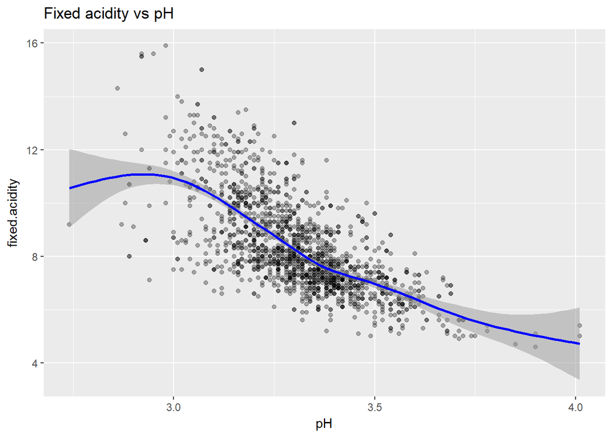

The feature pH has a strong negative correlation with fixed acidity. The truth value of this claim is high as it is known popularly that as pH value decreases, acidity increases.

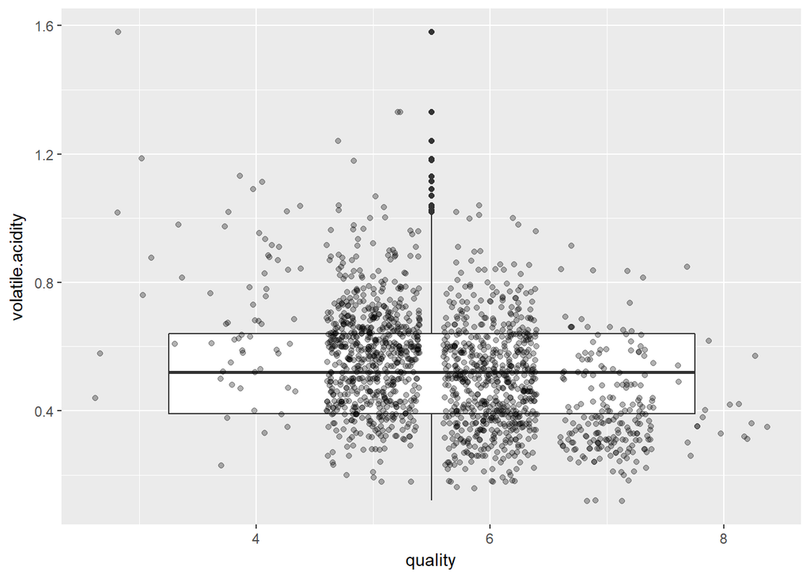

```
## $title
## [1] "Volatile acidity vs Quality"
##
## $subtitle
## NULL
##
## attr(,"class")
## [1] "labels"
```

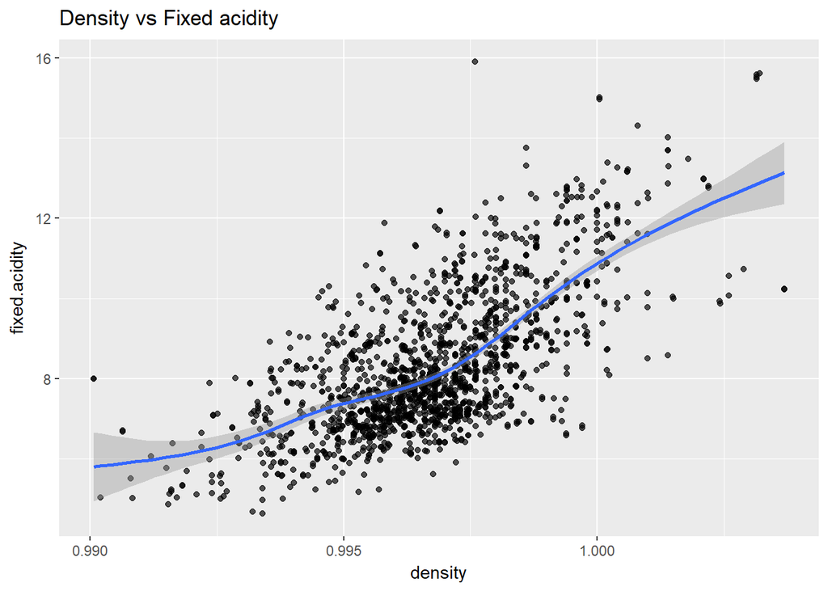

As Density increases, the fixed acidity of the wine also increases, making sense of a positive correlation.

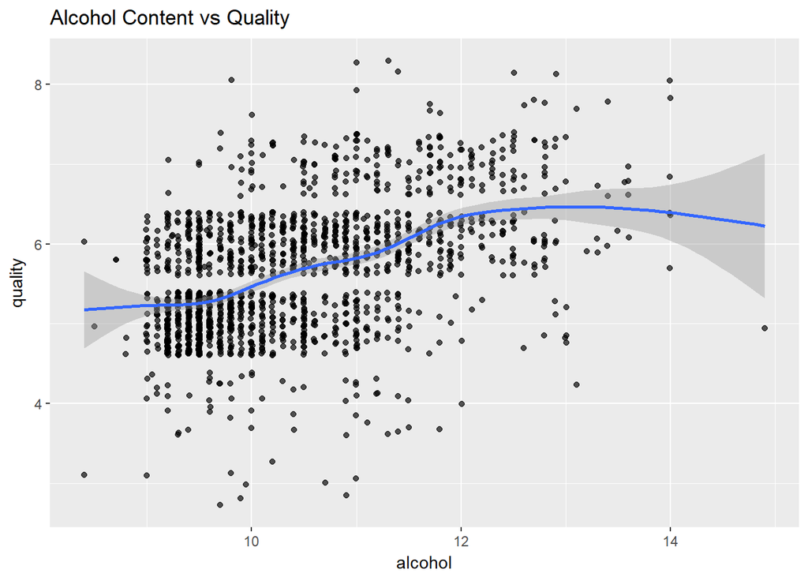

Alcohol and quality appear to be slightly correlatable. Lower quality wines tended to have lower alcohol contents.

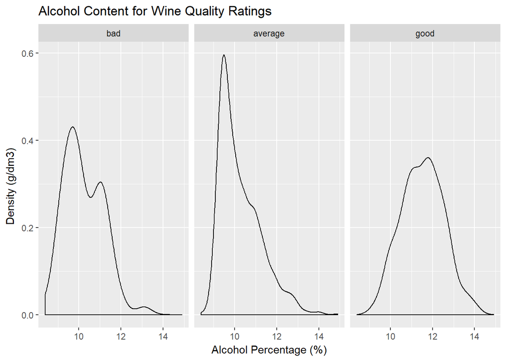

Alcohol content definitely affects the wine quality rating. The effect is not a strong one, and even for a given rating, there is significant variability.

# Bivariate Analysis

Citric acid and fixed acidity have a strong positive correlation of 0.7, while citrict acid and volatile acidity have a moderate negative correlation of -0.6. Density and fixed acidity are two features with strong positive correlation of 0.7. Negative correlation between alcohol and density. An expected strong negative correlation between pH and fixed and citric acid. A surprising positive correlation between pH and volatile acidity, since a higher pH value means less acidity, but a higher volatile acidity means more acidity.

The Negative Correlation between pH and fixed acity was the strongest relationship found.

# Multivariate Plots Section

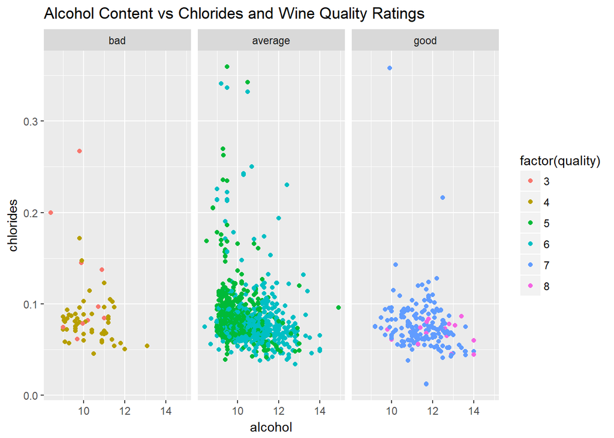

Adding a third varialbe chloride to the Alcohol vs Quality added little reversal of insight to the plotUnusually bright chloride points occured at different qualities and alcohol content points with no discernable pattern. Higher alcohol content and lower chloride content appears to correlate to higher quality wines.

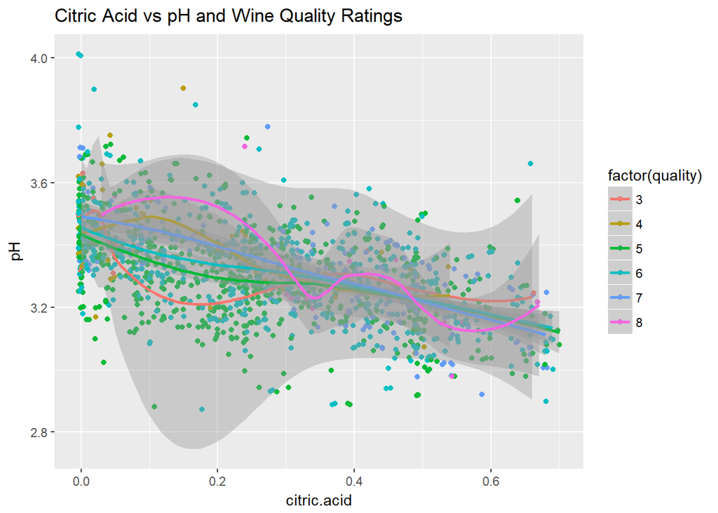

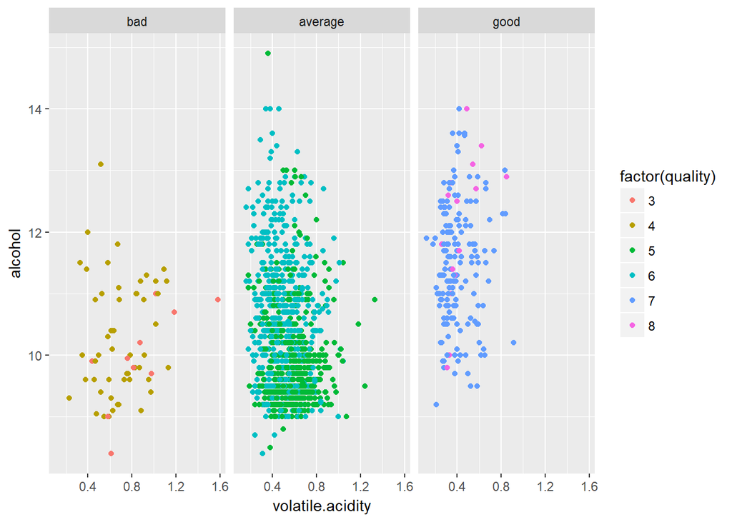

It looks like Volatile acid has just the negative effect. Good quality redwines have low concentrations of volatile acid and high amounts of alcohol.

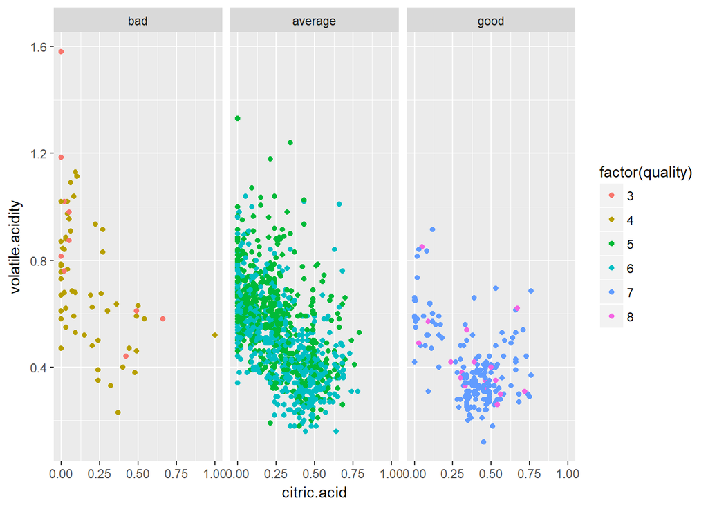

High amounts of Citric Acid and low Volatile Acids seems to produce better Wines.

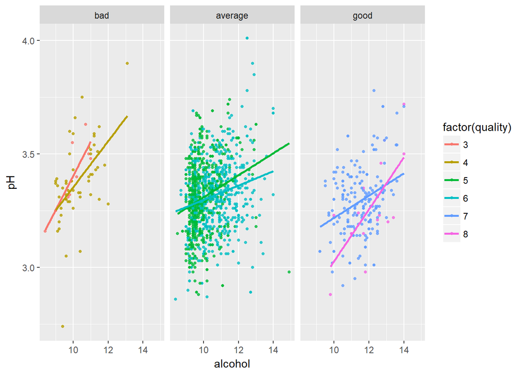

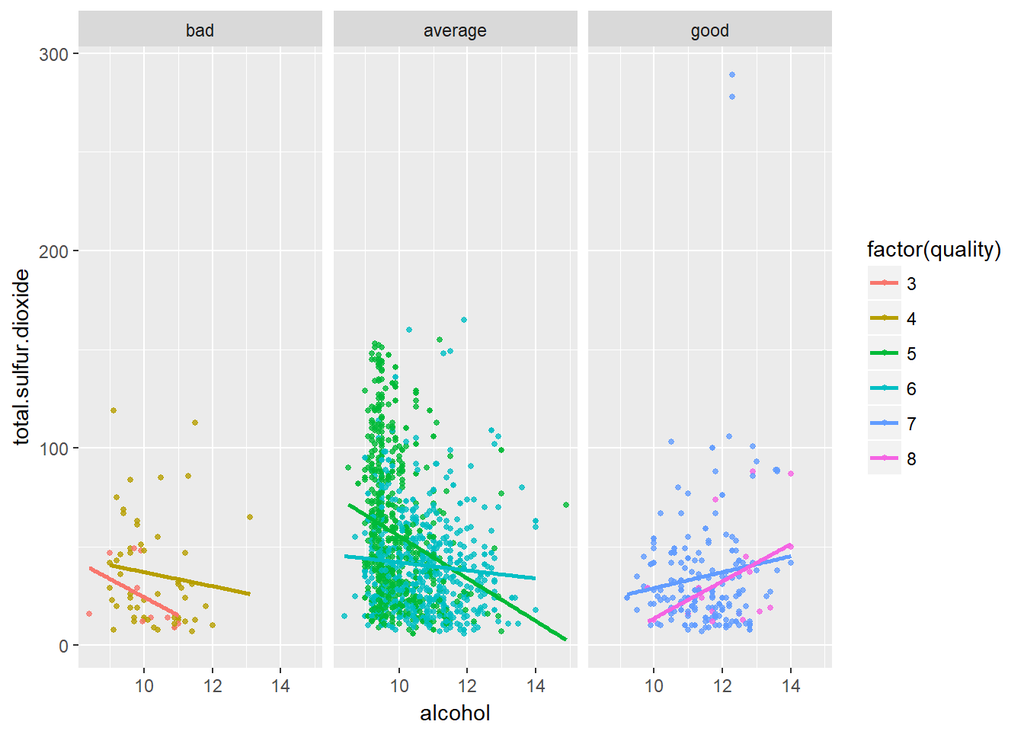

Lower Sulphur Dioxide seems to produces better wine even though there are some high outliers for better wine with high Sulphur Dioxide.

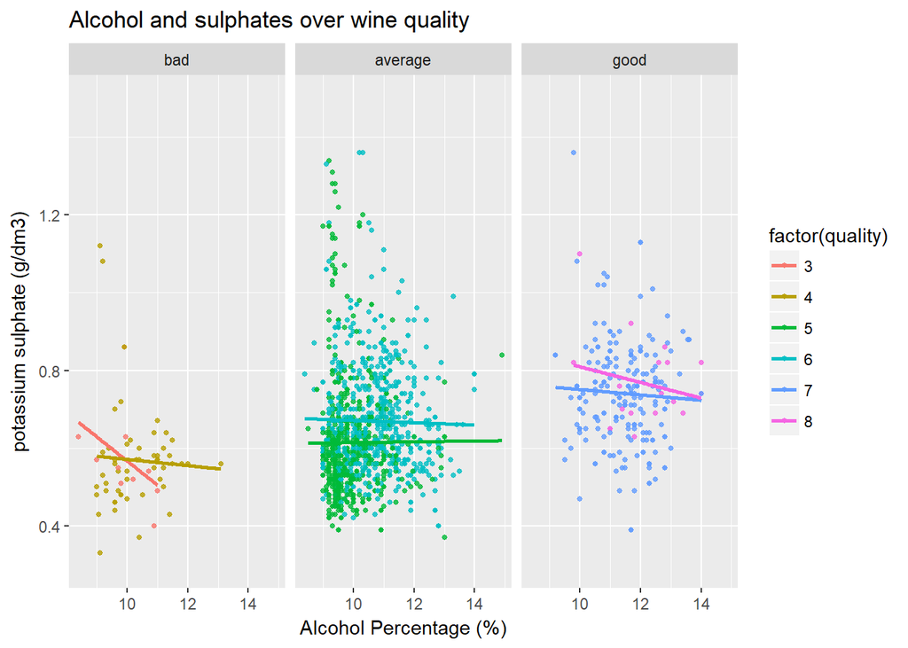

The best quality wines have high values for both Alcohol percentage and Sulphate concentration implying that High alcohol contents and high sulphate concentrations together seem to produce better wines.

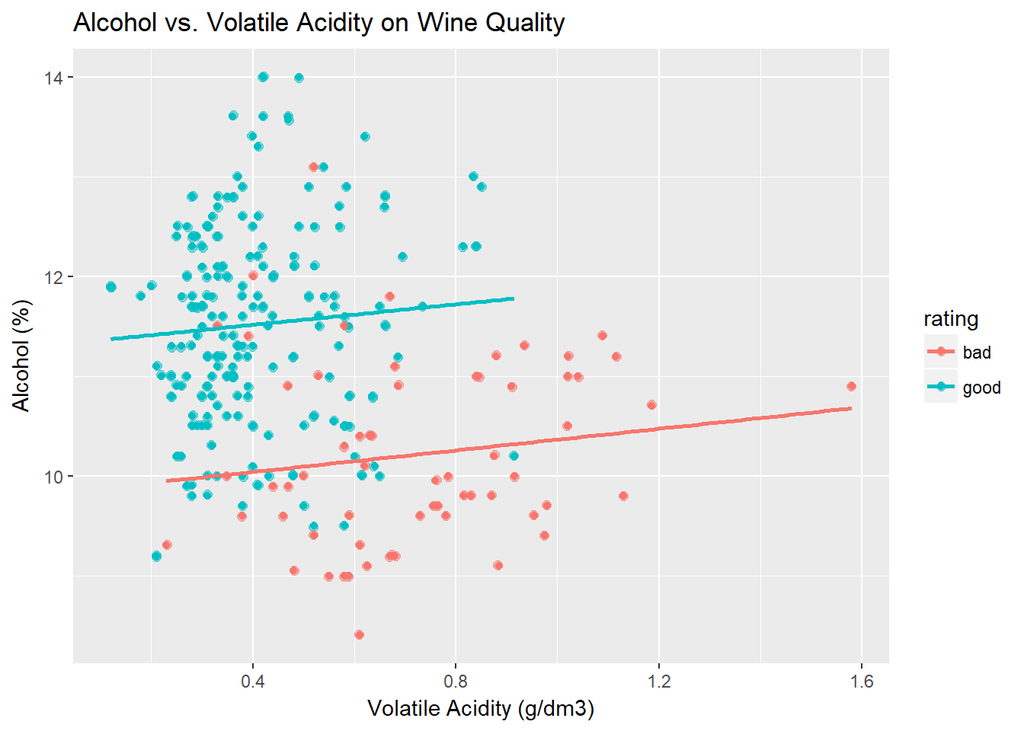

High volatile acidity made wine quality down. We notice that the lines make is more clear to see the relationship alcohol and volatile acidity by rating.

# Multivariate Analysis

High alcohol contribute to good quality of wine, adding citric acid will influence the quality of wine positively, while adding volatile acid influences the quality of wine negatively.Typically, pH is considered important when assessing wine quality, however the data does not show an appreciable correlation

Citric Acid, even though weakly correlated plays a part in improving the wine quality.

# Final Plots and Summary

### Plot One

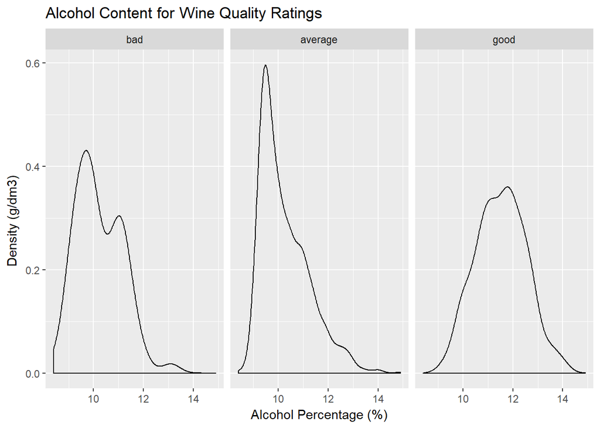

### Description One

Alcohol content definitely affects the wine quality rating. The effect is not a strong one, and even for a given rating, there is significant variability. The plot clearly visualizes the shift in alcohol percentage as the quailty of the wine gets better.

### Plot Two

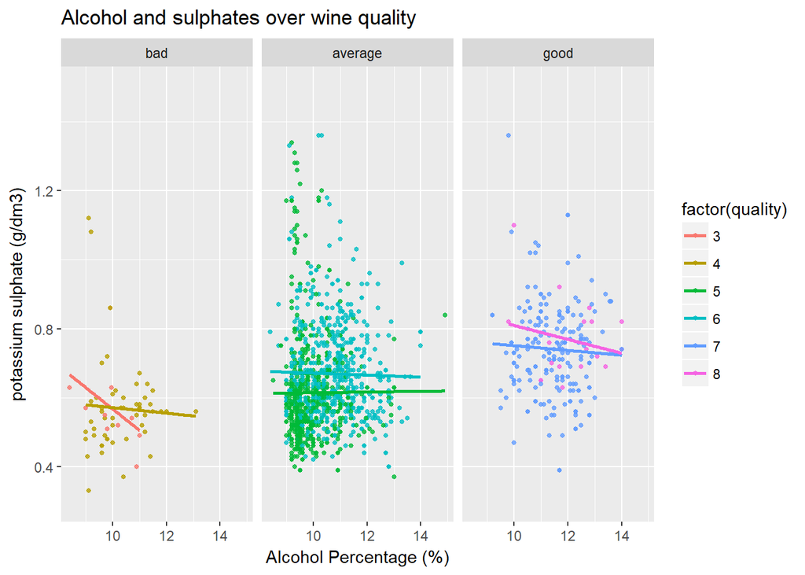

### Plot Three

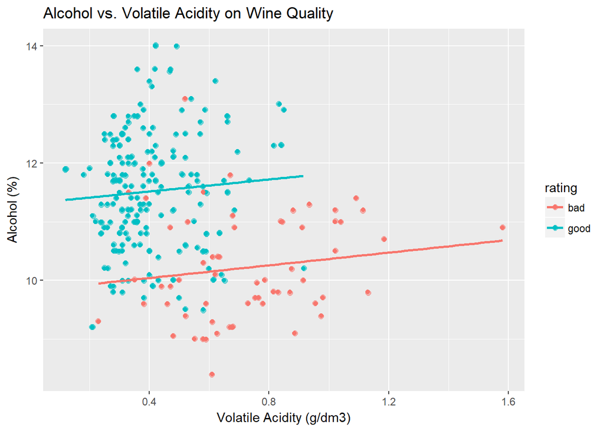

### Description Three

We had to subset the data to take off the ‘average’ wines as it was just overplotting the chart.High volatile acidity made wine quality down. We notice that the lines make is more clear to see the relationship alcohol and volatile acidity by rating. High quality wine have a combination of high alcohol content and low volatile acidity. ——

# Reflection

In this dataset more than 70% of the wines are of avergae quality betwen 5 & 6. If we could have a dataset of more observations and uniform quality of wines. Then we will be able to perform a better analysis. In the final part of the analysis, multivariate plots were plotted to see if there were some interesting combinations of variables which together affected the overall quality of the wine. For future analysis, better features of the wine samples such as the tastes of the wines, could be given which could lead us to a better analysis between the alcoholic and sugar content of the wines.